# Revisao4

```r
forecast_15anos <- forecast(usmelec.111, h = 15)
```

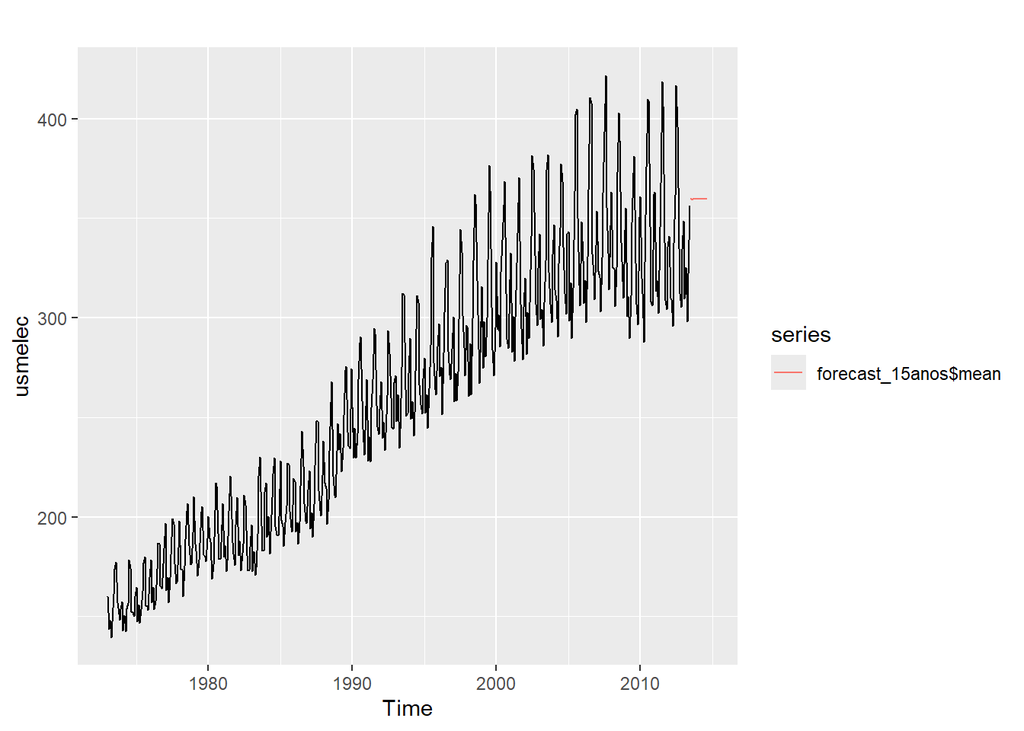

```r
autoplot(usmelec) +
  autolayer(forecast_15anos$mean)
```

```r
  labs(title = "Previsão para os Próximos 15 Anos",
       x = "Tempo",
       y = "Produção de Eletricidade") +
  theme_minimal()
```

5. Considere os dados mcopper (package: expsmooth)
1. Se necessário, encontre uma transformação Box-Cox adequada para os dados.

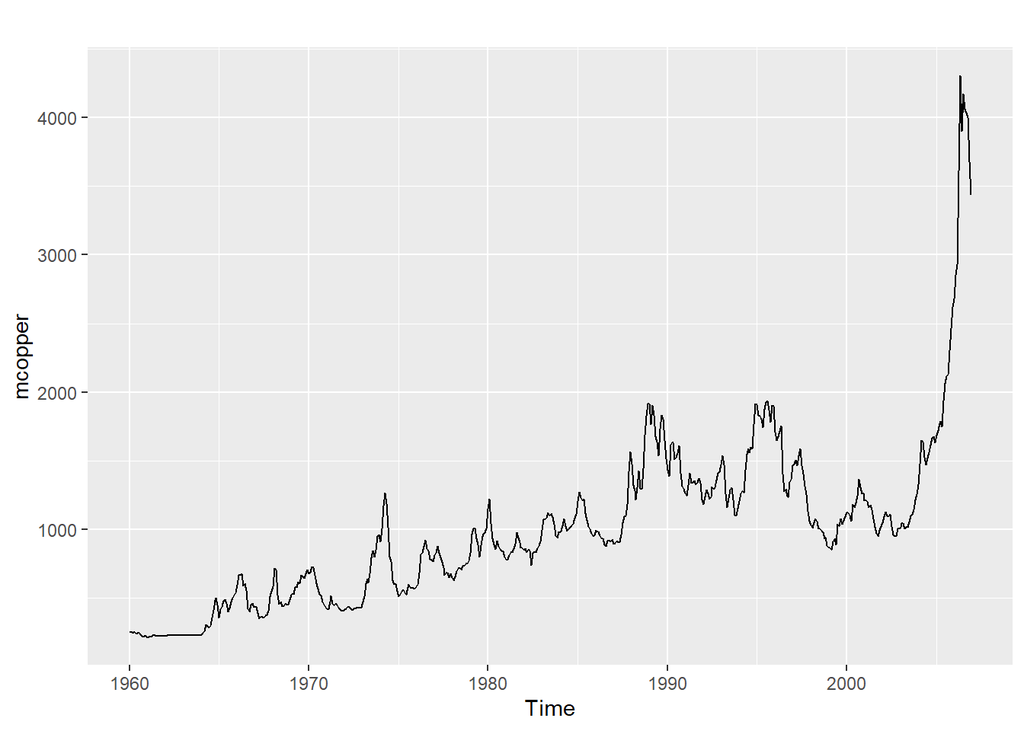

```r
autoplot(mcopper)
```

2. Ajuste um modelo ARIMA adequado aos dados transformados utilizando a função auto.arima().

```r
(auto.mcopper <- auto.arima(mcopper))
```

```
## Series: mcopper
## ARIMA(0,1,1)
##
## Coefficients:
##          ma1
##       0.2900
## s.e.  0.0419
##
## sigma^2 = 6026:  log likelihood = -3248.53
## AIC=6501.07   AICc=6501.09   BIC=6509.73
```

3. Experimente outros modelos plausíveis, experimentando as ordens escolhidas.

```r
(m1 <- Arima(mcopper, order = c(1,1,0)))
```

```
## Series: mcopper
## ARIMA(1,1,0)
##
## Coefficients:
##          ar1
##       0.2700
## s.e.  0.0409
##
## sigma^2 = 6052:  log likelihood = -3249.74
## AIC=6503.47   AICc=6503.5   BIC=6512.14
```

```r
(m2 <- Arima(mcopper, order = c(1,1,1)))
```

```
## Series: mcopper
## ARIMA(1,1,1)
##
## Coefficients:
##           ar1     ma1
##       -0.1091  0.3948
## s.e.   0.2573  0.2453
##
## sigma^2 = 6035:  log likelihood = -3248.45
## AIC=6502.9   AICc=6502.94   BIC=6515.9
```

```r
(m3 <- Arima(mcopper, order = c(0,1,2)))
```

```
## Series: mcopper
## ARIMA(0,1,2)
##
## Coefficients:
##          ma1      ma2
##       0.2888  -0.0113
## s.e.  0.0418   0.0454
##
## sigma^2 = 6036:  log likelihood = -3248.5
## AIC=6503   AICc=6503.05   BIC=6516
```

```r
(m4 <- Arima(mcopper, order = c(2,1,0)))
```

```
## Series: mcopper
## ARIMA(2,1,0)
##
## Coefficients:
##          ar1      ar2
##       0.2820  -0.0482
## s.e.  0.0422   0.0428
##
## sigma^2 = 6049:  log likelihood = -3249.1
## AIC=6504.21   AICc=6504.25   BIC=6517.21
```

4. Escolha o que pensa ser o melhor modelo e efetue um diagnóstico aos residuos.

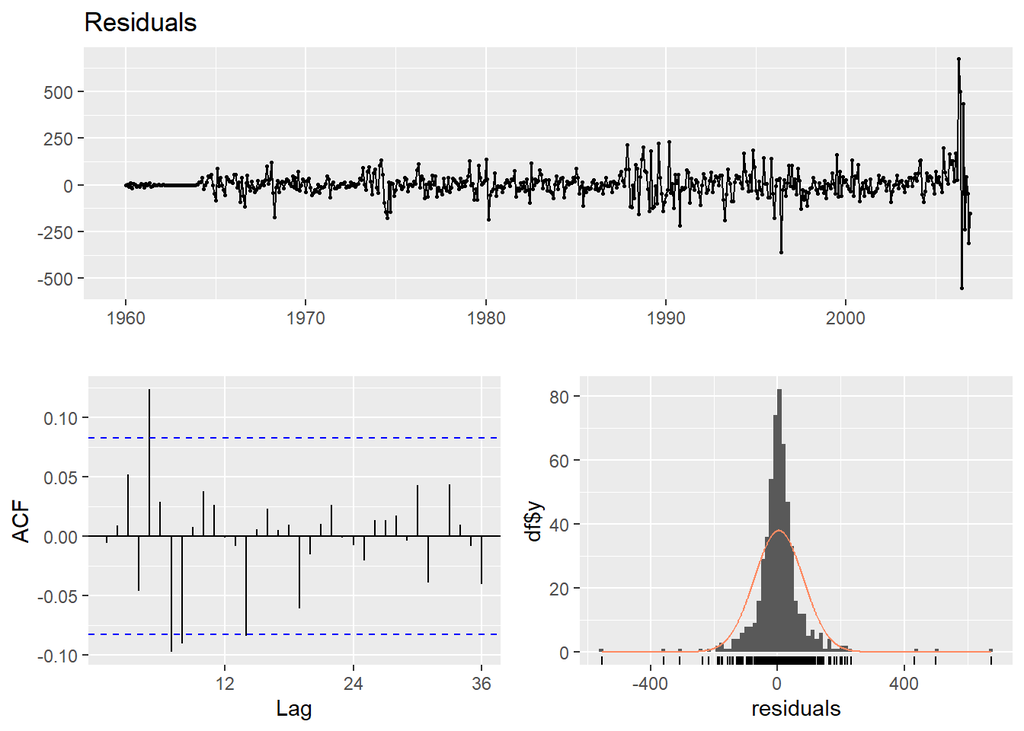

```
##
##  Ljung-Box test
##
## data:  Residuals
## Q* = 30.716, df = 24, p-value = 0.1621
##
## Model df: 0.   Total lags used: 24
```

```r
checkresiduals(auto.mcopper$residuals)
```

5. Considerando este modelo, obtenha previsões. Acha que as previsões são razoáveis?

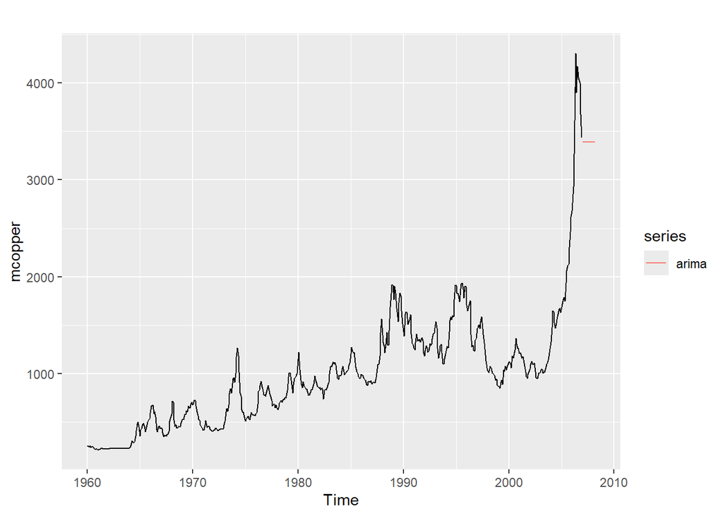

```r
forecast_arima <- forecast(auto.mcopper, h = 15)
autoplot(mcopper) +
  autolayer(forecast_arima$mean, series = "arima")
```

```r
  labs(title = "Previsão ARIMA(0,1,1) para mcopper")
```

```
## $title
## [1] "Previsão ARIMA(0,1,1) para mcopper"
##
## attr(,"class")
## [1] "labels"
```

6. Compare os resultados com os que obteria utilizando a função ets() (sem transformação).

```r
modelo_ets <- ets(mcopper)
summary(modelo_ets)
```

```
## ETS(M,Ad,N)
##
## Call:
## ets(y = mcopper)
##
##   Smoothing parameters:
##     alpha = 0.9999
##     beta  = 0.2141
##     phi   = 0.8
##
##   Initial states:
##     l = 265.0541
##     b = -3.9142
##
##   sigma:  0.0632
##
##      AIC     AICc      BIC
## 8052.038 8052.189 8078.049
##
## Training set error measures:
##                    ME     RMSE      MAE       MPE     MAPE      MASE      ACF1
## Training set 2.691483 78.87699 46.76047 0.1883633 4.503026 0.2103854 0.1052005
```

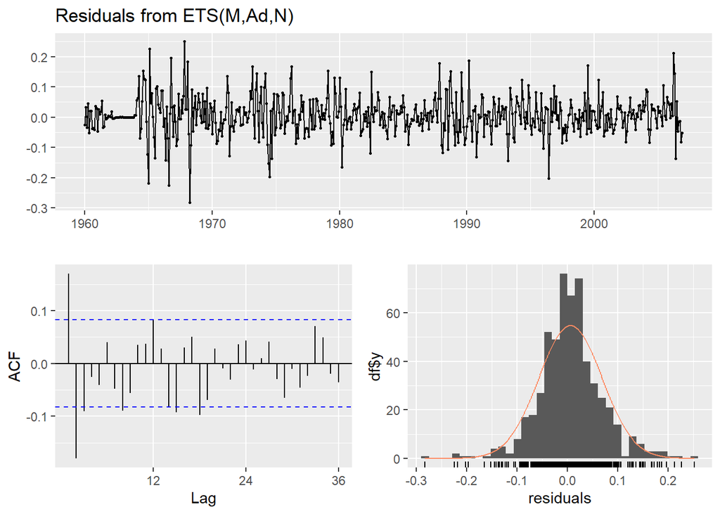

```
##
##  Ljung-Box test
##
## data:  Residuals from ETS(M,Ad,N)
## Q* = 77.585, df = 24, p-value = 1.469e-07
##
## Model df: 0.   Total lags used: 24
```

```r
checkresiduals(modelo_ets)
```

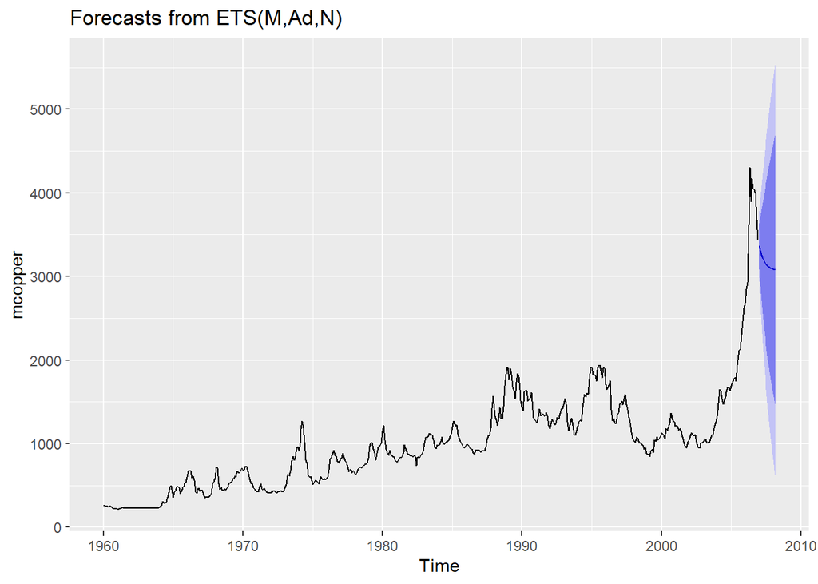

```r
forecast_ets <- forecast(modelo_ets, h = 15)
autoplot(forecast_ets)
```